# Experiment 2

## Stability of subject-level estimates across sessions

```r
# add morph type
for (morph in morphs) {
  dpse_ses1[[morph]]$subject <- row.names(dpse_ses1[[morph]])
  dpse_ses2[[morph]]$subject <- row.names(dpse_ses2[[morph]])
}
# get dpse in long format for plotting
dpse_ses1_long <-
  ldply(
    lapply(dpse_ses1, function(x) gather(x, pos, pse, -subject)),
    data.frame) %>%
  mutate(morph_type=.id, session='1')
dpse_ses2_long <-
  ldply(
    lapply(dpse_ses2, function(x) gather(x, pos, pse, -subject)),
    data.frame) %>%
  mutate(morph_type=.id, session='2')
dpse <-
  rbind(dpse_ses1_long, dpse_ses2_long) %>%
  mutate(pos_num=mapvalues(pos,
                           paste('pos', c(1, 3, 5, 7), sep=''),
                           c(1, 3, 5, 7)*45))
dpse$pos_num <- factor(dpse$pos_num, levels=c(1, 3, 5, 7)*45)
```

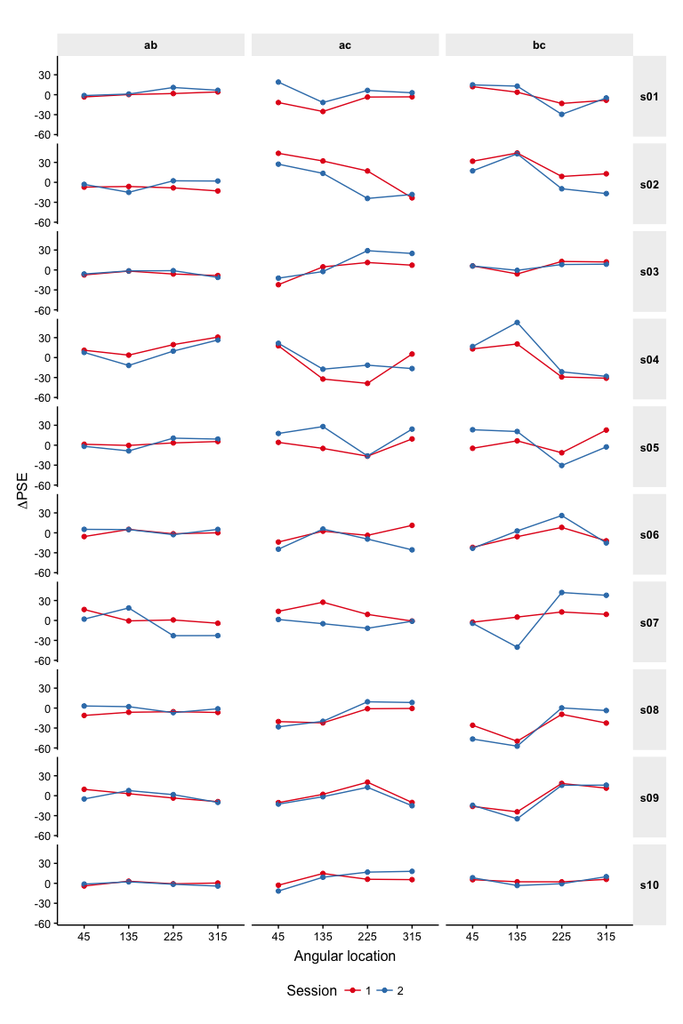

Average the estimates across sessions and plot them

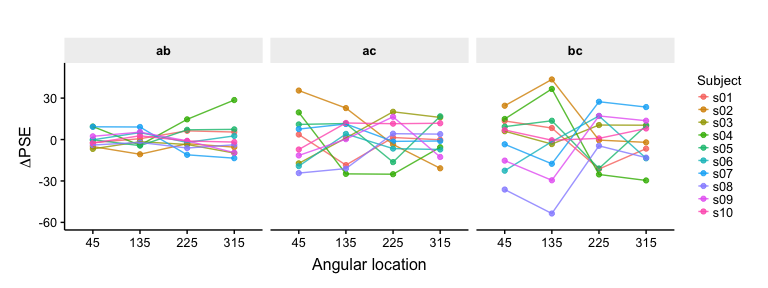

```r
dpse %>%
  group_by(subject, morph_type, pos_num) %>%
  summarise(pse=mean(pse)) %>%
  ggplot(aes(pos_num, pse*100, color=subject, group=subject)) +
  geom_point(alpha=0.8) +
  geom_line(alpha=0.8) +
  facet_wrap(~morph_type, nrow=1) +
  theme_Publication() +
  labs(x='Angular location', y=TeX('$\\Delta$PSE'), color='Subject') +
  scale_y_continuous(limits=c(-60, 50)) +
  theme(#legend.position=c(0.95, 0.15),
        legend.direction='vertical',
        legend.position='right',
        legend.key.size=unit(.8, 'picas'),
        legend.title=element_text(size=10))
```

```r
ggsave('../img/dpse_subjects.png', width=8, height=3)
```

Let’s also plot an example fit for subject s10

```r
# get the data to plot individual points
df_s10_plot_ab <-
  df %>%
  filter(subject == 's10', session == '1') %>%
  filter(morph_type == 'ab', pos_num %in% c('225', '315'))
df_s10_plot_ac <-
  df %>%
  filter(subject == 's10', session == '1') %>%
  filter(morph_type == 'ac', pos_num %in% c('135', '315'))
df_s10_plot_bc <-
  df %>%
  filter(subject == 's10', session == '1') %>%
  filter(morph_type == 'bc', pos_num %in% c('135', '315'))
df_s10_plot <-
  rbind(df_s10_plot_ab, df_s10_plot_ac, df_s10_plot_bc)
# now get the pse values to plot
psep1_plot <-
psep %>%
  filter(session == '1') %>%
  arrange(pos, morph_type)
dpse1_plot <-
dpse %>%
  filter(subject == 's10', session == '1') %>%
  arrange(pos, morph_type) %>%
  mutate(dpse=pse) %>%
  select(morph_type, pos, pos_num, dpse)
pse_s10_plot <- merge(psep1_plot, dpse1_plot)
pse_s10_plot <-
pse_s10_plot %>%
  mutate(tpse=(pse+dpse)*100+50)
```

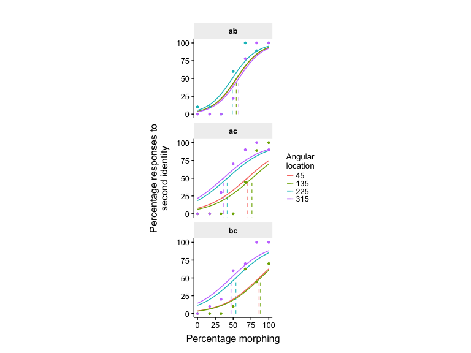

```r
predict_subj %>%
  filter(subject == 's10', session == '1') %>%
  ggplot(aes(morph_resc*100 + 50, pred*100, color=as.factor(pos_num))) +
  geom_segment(aes(x=tpse, xend=tpse, y=-10, yend=50), alpha=0.8, linetype='dashed', data=pse_s10_plot) +
  geom_line() +
  facet_wrap(~morph_type, ncol=1) +
  coord_equal(ylim=c(-0.4, 101)) +
  theme_Publication() +
  theme(#legend.position=c(0.95, 0.15),
        legend.direction='vertical',
        legend.position='right',
        legend.key.size=unit(.8, 'picas'),
        legend.title=element_text(size=10)) +
  labs(x='Percentage morphing', y='Percentage responses to\nsecond identity', color='Angular\nlocation') +
  stat_summary(aes(morph, response_bin), fun.y=function(x) sum(x)/length(x)*100, geom='point',
               data=df_s10_plot, size=0.9, show.legend=F)
```

```r
ggsave('../img/examplefit_s10.png', width=8, height=6)
```

Correlation of subject-level estimates across sessions

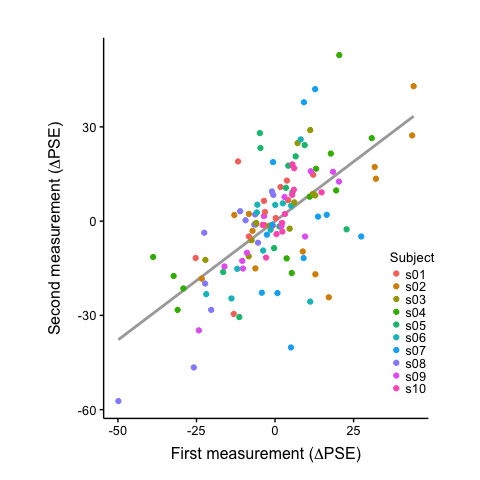

```r
dpse_wide <-
dpse %>%
  spread(session, pse) %>%
  mutate(session1=.$'1', session2=.$'2')
ggplot(dpse_wide, aes(session1*100, session2*100, color=subject)) +
  geom_smooth(method='lm', color='darkgray', se=F) +
  geom_point() +
  labs(x=TeX('First measurement ($\\Delta$PSE)'),
       y=TeX('Second measurement ($\\Delta$PSE)'),
       color='Subject') +
  theme_Publication() +
  coord_equal() +
  theme(legend.position=c(0.95, 0.25),
        legend.direction='vertical',
        legend.key.size=unit(.8, 'picas'),
        legend.title=element_text(size=10))
```

```r
  #coord_equal(xlim=c(-60, 45), ylim=c(-60, 45)) +
  #scale_x_continuous(breaks=seq(-60, 40, 20)) +
  #scale_y_continuous(breaks=seq(-60, 40, 20))
ggsave('../img/pse_subj_scatter.png', width=5, height=5)
```

And these are the correlations.

```r
set.seed(23448)
bootES(dpse_wide[c('session1', 'session2')], R=10000)
```

```
95.00% bca Confidence Interval, 10000 replicates
Stat        CI (Low)    CI (High)   bias        SE
0.639       0.499       0.750       -0.003      0.064
```

```r
cor.test(dpse_wide$session1, dpse_wide$session2)
```

```
    Pearson's product-moment correlation

data:  dpse_wide$session1 and dpse_wide$session2
t = 9.0205, df = 118, p-value = 3.997e-15
alternative hypothesis: true correlation is not equal to 0
95 percent confidence interval:
 0.5190456 0.7340393
sample estimates:
      cor
0.6388518
```

## Within- vs. between-subjects correlation

Let’s compute the correlation between the first and the second session

```r
cor_ses12 <- list()
for (morph in morphs) {
  this_cor <- cor(t(dpse_ses1[[morph]][, 1:4]), t(dpse_ses2[[morph]][, 1:4]))
  # make it symmetric
  this_cor <- (this_cor + t(this_cor))/2.
  cor_ses12[[morph]] = this_cor
}
# make a dataframe in long format
make_cor_long <- function(cor) {
  within <- diag(cor)
  between <- cor[lower.tri(cor)]

  df_within_between <- data.frame(corr=c(within, between),
                                  type=c(rep('within', length(within)),
                                         rep('between', length(between)))
                                  )
  return(df_within_between)
}
cor_ses12_long <- sapply(cor_ses12, make_cor_long, simplify=F, USE.NAMES=T)
# add everything together for plotting
cor_ses12_long_plot <- ldply(cor_ses12_long, data.frame)
```

We can check whether the estimates are consistent across sessions, and also subject-specific, by comparing the within-subject correlations with the between-subject correlations. We will compute the bootstrapped difference $\text{Within} - \text{Between}$.

```r
require(bootES)
require(broom)
bootstrap_withinbetween <- function(corr_df) {
  b <- bootES(corr_df,
              data.col='corr', group.col='type',
              contrast=c(within=1, between=-1), R=10000)
  return(b)
}
set.seed(124)
boot_cis <- sapply(cor_ses12_long,
                   bootstrap_withinbetween,
                   simplify=F,
                   USE.NAMES=T)
extract_cis <- function(bootes_out) {
  t0 <- bootes_out$t0
  bounds <- bootes_out$bounds
  df <- data.frame(t0=t0, lci=bounds[1], rci=bounds[2])
  return(df)
}
extract_distribution <- function(bootes_out) {
  df <- data.frame(t=bootes_out$t)
  return(df)
}
boot_cis_df <- ldply(boot_cis, extract_cis)
boot_dist_df <- ldply(boot_cis, extract_distribution)
```

And finally plot them

```
Ignoring unknown aesthetics: y
```

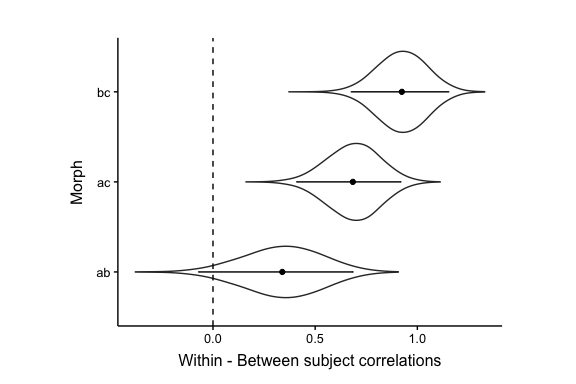

```r
ggplot(data=boot_dist_df, aes(.id, t)) +
  geom_violin(adjust=2) +
  geom_errorbar(data=boot_cis_df, aes(ymin=lci, ymax=rci, y=t0), width=0.01) +
  geom_point(data=boot_cis_df, aes(y=t0)) +
  geom_hline(yintercept=0, linetype='dashed') +
  labs(x='Morph', y='Within - Between subject correlations') +
  theme_Publication() +
  coord_flip() +
  theme(aspect.ratio=3/4)
```

And these are the values

```r
boot_cis_df %>% arrange(.id)
```

| .id | t0 | lci | rci |
| --- | --- | --- | --- |
| ab | 0.3391053 | -0.07029715 | 0.6855457 |
| ac | 0.6843746 | 0.40988453 | 0.9196337 |
| bc | 0.9241400 | 0.67701408 | 1.1536785 |

Let’s also do it separately for within and between

```r
bootstrap <- function(corr_df) {
  b <- bootES(corr_df,
              data.col='corr', R=10000)
  return(b)
}
cor_ses12_long_within <- sapply(cor_ses12_long,
                                function(x) filter(x, type=='within'),
                                simplify=F,
                                USE.NAMES=T)
cor_ses12_long_between <- sapply(cor_ses12_long,
                                function(x) filter(x, type=='between'),
                                simplify=F,
                                USE.NAMES=T)
set.seed(3243)
bs_within <- ldply(
  lapply(cor_ses12_long_within, bootstrap),
  extract_cis)
set.seed(23423)
bs_between <- ldply(
  lapply(cor_ses12_long_between, bootstrap),
  extract_cis)
```

```r
bs_within %>% arrange(.id)
```

| .id | t0 | lci | rci |
| --- | --- | --- | --- |
| ab | 0.3189388 | -0.1007527 | 0.6151277 |
| ac | 0.6179501 | 0.3513429 | 0.7855175 |
| bc | 0.8490889 | 0.6115145 | 0.9463881 |

```r
bs_between %>% arrange(.id)
```

| .id | t0 | lci | rci |
| --- | --- | --- | --- |
| ab | -0.02016651 | -0.1510517 | 0.10897154 |
| ac | -0.06642447 | -0.2118914 | 0.08072318 |
| bc | -0.07505119 | -0.2658810 | 0.12166054 |

## Correlation with familiarity ratings

```r
df_quest <- read_csv('../data/questionnaire.csv',
                     col_types='ccddddddddddddd')
```

We are going to create a composite score by simply averaging the questions related to closeness.

```r
# add composite score
df_quest <-
df_quest %>%
  # everybody got the name right
  select(-name) %>%
  rowwise() %>%
  # Let's make a composite score by averaging ios, wescale, sci1, sci2
  mutate(compscore=mean(c(ios, wescale, sci1, sci2)))
```

Let’s start simply by looking at the average values for each id

```r
df_quest_long <-
df_quest %>%
  gather(scale, value, -subject, -stim)
```

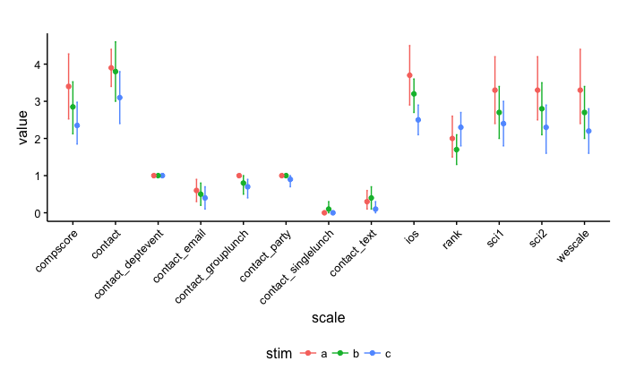

```r
df_quest_long %>%
  ggplot(aes(scale, value, color=stim)) +
  stat_summary(fun.data=mean_cl_boot, geom='errorbar', width=0.1, position=position_dodge(w=0.3)) +
  stat_summary(fun.y=mean, geom='point', position=position_dodge(w=0.3)) +
  theme_Publication() +
  theme(axis.text.x=element_text(angle=45, hjust=1))
ggsave('../img/scores.png', width=8, height=6)
```

```r
# compute a score of deviance from 0 for each subject and morph type
# basically the variance
dpse_deviance <-
dpse %>%
  group_by(subject, morph_type, pos_num) %>%
  summarise(pse=mean(pse)) %>%
  group_by(subject, morph_type) %>%
  summarise(psescore=sum(pse^2))
# now for each subject compute the average score for the morphs
df_quest_avg <-
df_quest %>%
  select(subject, stim, compscore) %>%
  spread(stim, compscore) %>%
  rowwise() %>%
  mutate(score_ab=mean(c(a, b)),
         score_bc=mean(c(b, c)),
         score_ac=mean(c(a, c))) %>%
  select(-a, -b, -c) %>%
  gather(morph_type, score, -subject)
df_quest_avg$morph_type <-
  mapvalues(df_quest_avg$morph_type,
            c('score_ab', 'score_ac', 'score_bc'),
            c('ab', 'ac', 'bc'))
df_quest_deviance <-
df_quest_avg %>%
  arrange(subject, morph_type) %>%
  merge(dpse_deviance)
```

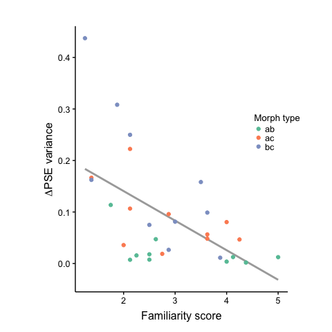

```r
ggplot(aes(score, psescore, color=morph_type), data=df_quest_deviance) +
  geom_smooth(method='lm', aes(group=1), se=F, color='darkgray') +
  geom_point() +
  theme_Publication() +
  coord_fixed(ratio=10) +
  labs(x='Familiarity score', y=TeX('$\\Delta$PSE variance'), color='Morph type') +
  theme(legend.position=c(0.95, 0.6),
        legend.direction='vertical',
        legend.key.size=unit(.8, 'picas'),
        legend.title=element_text(size=10)) +
  scale_color_brewer(palette='Set2')
```

```r
ggsave('../img/psequest_scatter.png', width=5, height=5)
```

```r
cor.test(df_quest_deviance$score, df_quest_deviance$psescore)
```

```
    Pearson's product-moment correlation

data:  df_quest_deviance$score and df_quest_deviance$psescore
t = -3.5895, df = 28, p-value = 0.001248
alternative hypothesis: true correlation is not equal to 0
95 percent confidence interval:
 -0.7666035 -0.2520935
sample estimates:
       cor
-0.5613776
```

```r
set.seed(324)
bootES(df_quest_deviance[c('score', 'psescore')], R=10000)
```

```
95.00% bca Confidence Interval, 10000 replicates
Stat        CI (Low)    CI (High)   bias        SE
-0.561      -0.708      -0.298      0.006       0.100
```

## Is it personal familiarity or is it contact?

```r
df_quest_contact_avg <-
df_quest %>%
  select(subject, stim, contact) %>%
  spread(stim, contact) %>%
  rowwise() %>%
  mutate(ab=mean(c(a, b)),
         bc=mean(c(b, c)),
         ac=mean(c(a, c))) %>%
  select(-a, -b, -c) %>%
  gather(morph_type, contact, -subject)
df_contact_deviance <-
df_quest_deviance %>%
  arrange(subject, morph_type) %>%
  merge(df_quest_contact_avg)
```

Are familiarity score and contact correlated?

```r
cor.test(df_contact_deviance$score, df_contact_deviance$contact)
```

```
    Pearson's product-moment correlation

data:  df_contact_deviance$score and df_contact_deviance$contact
t = 2.6517, df = 28, p-value = 0.01304
alternative hypothesis: true correlation is not equal to 0
95 percent confidence interval:
 0.1046298 0.6959508
sample estimates:
      cor
0.4480113
```

```r
set.seed(324)
bootES(df_contact_deviance[c('score', 'contact')], R=10000)
```

```
95.00% bca Confidence Interval, 10000 replicates
Stat        CI (Low)    CI (High)   bias        SE
0.448       0.168       0.675       -0.002      0.130
```

```r
print(paste("Log-likelihood ratio:", lr, "pvalue:", plr))
```

```
[1] "Log-likelihood ratio: 6.3024453723185 pvalue: 0.0120571535553395"
```

```r
# from http://www.statmethods.net/advstats/bootstrapping.html
bs <- function(formula, data, indices) {
  d <- data[indices,] # allows boot to select sample
  fit <- lm(formula, data=d)
  return(coef(fit))
}
set.seed(234)
results <- boot(data=df_contact_deviance, statistic=bs,
                R=10000, formula=psescore ~ score + contact)
t0 <- results$t0
conf <- c()
for (i in 1:length(t0)) {
  b <- boot.ci(results, type='bca', index=i)
  conf <- rbind(conf, b$bca[4:5])
}
df_ci <- data.frame(t0=t0, lci=conf[,1], rci=conf[,2])
```

```r
df_ci
```

|  | t0 | lci | rci |
| --- | --- | --- | --- |
| (Intercept) | 0.36532810 | 0.21465489 | 0.55147559 |
| score | -0.03894801 | -0.07431666 | -0.01631785 |
| contact | -0.04522674 | -0.08609399 | -0.01694056 |

Now compute partial correlations

```r
partialout_variable <- function(df, x, y, z) {
  mx <- lm(df[[x]] ~ df[[z]])
  my <- lm(df[[y]] ~ df[[z]])
  df_out <- data.frame(mx$residuals, my$residuals)
  names(df_out) <- c(x, y)
  return(df_out)
}
# Make plots of partial correlation with residuals
partial_contact <- partialout_variable(df_contact_deviance, "psescore", "score", "contact")
partial_score <- partialout_variable(df_contact_deviance, "psescore", "contact", "score")
cor.test(partial_contact$psescore, partial_contact$score)
```

```
    Pearson's product-moment correlation

data:  partial_contact$psescore and partial_contact$score
t = -2.4183, df = 28, p-value = 0.02235
alternative hypothesis: true correlation is not equal to 0
95 percent confidence interval:
 -0.67487275 -0.06515499
sample estimates:
       cor
-0.4156671
```

```r
cor.test(partial_score$psescore, partial_score$contact)
```

```
    Pearson's product-moment correlation

data:  partial_score$psescore and partial_score$contact
t = -2.5585, df = 28, p-value = 0.01621
alternative hypothesis: true correlation is not equal to 0
95 percent confidence interval:
 -0.68771457 -0.08898003
sample estimates:
       cor
-0.4352951
```

```r
set.seed(3242)
bootES(partial_contact[c('psescore', 'score')], R=10000)
```

```
95.00% bca Confidence Interval, 10000 replicates
Stat        CI (Low)    CI (High)   bias        SE
-0.416      -0.610      -0.158      0.008       0.116
```

```r
bootES(partial_score[c('psescore', 'contact')], R=10000)
```

```
95.00% bca Confidence Interval, 10000 replicates
Stat        CI (Low)    CI (High)   bias        SE
-0.435      -0.619      -0.166      -0.001      0.113
```

```r
# add the morph types to partial_contact and partial_score
partial_contact$morph_type <- df_contact_deviance$morph_type
partial_score$morph_type <- df_contact_deviance$morph_type
```

```r
# just a theme to uniform scatters
theme_Publication_scatter <- function(base_size=12) {
  (theme_Publication(base_size=base_size) +
  theme(legend.position=c(0.95, 0.6),
        legend.direction='vertical',
        legend.key.size=unit(.8, 'picas'),
        legend.title=element_text(size=10),
        axis.title=element_text(size=10)))
}
```

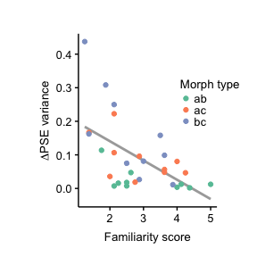

```r
ggplot(aes(score, psescore, color=morph_type), data=df_quest_deviance) +
  geom_smooth(method='lm', aes(group=1), se=F, color='darkgray') +
  geom_point() +
  coord_fixed(ratio=10) +
  labs(x='Familiarity score', y=TeX('$\\Delta$PSE variance'), color='Morph type') +
  theme_Publication_scatter() +
  scale_color_brewer(palette='Set2')
```

```r
ggsave('../img/psequest_scatter_psefam.png', width=3, height=3)
```

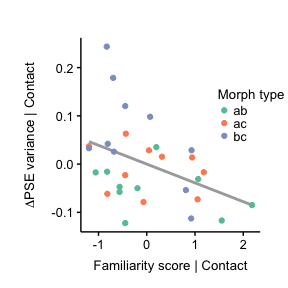

```r
ggplot(aes(score, psescore, color=morph_type), data=partial_contact) +
  geom_smooth(method='lm', aes(group=1), se=F, color='darkgray') +
  geom_point() +
  coord_fixed(ratio=10) +
  labs(x='Familiarity score | Contact', y=TeX('$\\Delta$PSE variance | Contact'), color='Morph type') +
  theme_Publication_scatter() +
  scale_color_brewer(palette='Set2')
```

```r
ggsave('../img/psequest_scatter_psefam_contact.png', width=3, height=3)
```

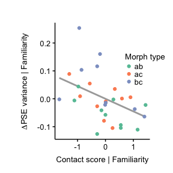

```r
ggplot(aes(contact, psescore, color=morph_type), data=partial_score) +
  geom_smooth(method='lm', aes(group=1), se=F, color='darkgray') +
  geom_point() +
  coord_fixed(ratio=10, expand=T) +
  labs(x='Contact score | Familiarity', y=TeX('$\\Delta$PSE variance | Familiarity'), color='Morph type') +
  theme_Publication_scatter() +
  scale_color_brewer(palette='Set2')
```

```r
ggsave('../img/psequest_scatter_psecontact_fam.png', width=3, height=3)
```

# PSE for individual identities

We are going to evaluate the bias towards specific identities, instead of pairs of morphs. To do so, we’ll fit a linear model predicting the PSE, taking the data of each pair of morphs containing the same identity. For example, to evaluate the bias for identity `a`, we’ll consider the PSE estimates for morphs `ab` and `ac` across the two sessions, and fit a linear model with participants, angular location, and their interaction as predictors.

```r
require(tidyverse)
require(lme4)
require(car)
require(broom)
```

First we compute the PSE for each participant by adding PSEp and DPSE.

```r
cols <- c('pos1', 'pos3', 'pos5', 'pos7')
pse_ses1 = list()
pse_ses2 = list()
# compute the PSE by adding PSEp to DPSE for each subject
for (morph in c('ac', 'ab', 'bc')) {
  psep <- psep_ses1[[morph]]
  dpse <- dpse_ses1[[morph]]
  pse <- (matrix(rep(psep[cols], 10), nrow=10, byrow=T) +
                       dpse[cols])*100 + 50
  pse$subject <- row.names(pse)
  pse_ses1[[morph]] <- pse

  psep <- psep_ses2[[morph]]
  dpse <- dpse_ses2[[morph]]
  pse <- (matrix(rep(psep[cols], 10), nrow=10, byrow=T) +
                       dpse[cols])*100 + 50
  pse$subject <- row.names(pse)
  pse_ses2[[morph]] <- pse
}
# now store it in long format
pse_ses1_long <-
  ldply(
    lapply(pse_ses1, function(x) mutate(x, subject=rownames(x)) %>% gather(pos, pse, -subject)),
    data.frame) %>%
  mutate(morph_type=.id, session='1')
pse_ses2_long <-
  ldply(
    lapply(pse_ses2, function(x) mutate(x, subject=rownames(x)) %>% gather(pos, pse, -subject)),
    data.frame) %>%
  mutate(morph_type=.id, session='2')
pse <-
  rbind(pse_ses1_long, pse_ses2_long) %>%
  mutate(pos_num=mapvalues(pos,
                           paste('pos', c(1, 3, 5, 7), sep=''),
                           c(1, 3, 5, 7)*45))
pse$pos_num <- factor(pse$pos_num, levels=c(1, 3, 5, 7)*45)
```

Let’s save it for later use.

```r
# save pse
pse_fn <- '../derivatives/pse.csv'
if (!file.exists(pse_fn)) {
  pse_ <- pse %>%
    select(subject, session, morph_type, pos_num, pse)
  write_csv(pse_, pse_fn)
}
```

Here we load the pre-estimated data

```r
pse <- read_csv('../derivatives/pse.csv', col_types='ciccd')
pse$morph_type <- as.factor(pse$morph_type)
pse$pos_num <- factor(pse$pos_num,
                      levels=c('45', '135', '225', '315'))
```

We set up a function to filter the data for each individual identity. Moreover, we make sure that the PSE value indicates consistently the bias with respect to the same identity.

```r
filter_dataset <- function(id, df) {
  identity2morphs <- list(a=c('ab', 'ac'),
                          b=c('ab', 'bc'),
                          c=c('bc', 'ac'))
  df_ <-
    df %>%
    filter(morph_type %in% identity2morphs[[id]]) %>%
    droplevels(.$morph_type)

  # put the PSE in the right order: > 50 indicates
  # more towards the identity of interest
  if (id == 'b') {
    df_ <-
    df_ %>%
      mutate(pse=ifelse(morph_type == 'ab', 100 - pse, pse))
  } else if (id == 'c') {
    df_ <-
    df_ %>%
      mutate(pse=100 - pse)
  }

  return(df_)
}
```

Finally we can fit the models

```r
ids <- c('a', 'b', 'c')
# split the datasets
pse_ids <- map(ids, filter_dataset, pse)
fit_model <- function(df) {
  df$subject <- as.factor(df$subject)
  df$pos_num <- as.factor(df$pos_num)
  contrasts(df$subject) <- contr.sum(length(unique(df$subject)))
  contrasts(df$pos_num) <- contr.sum(length(unique(df$pos_num)))

  return(lm(pse ~ subject * pos_num, data=df))
}
model_ids <-
  map(pse_ids, fit_model) %>%
  set_names(ids)
anova_model <-
  model_ids %>%
  map(Anova, type=3)
tidy_anova <-
  anova_model %>%
  map_df(tidy, .id='id')
```

And here are the results

```r
anova_model
```

```
$a
Anova Table (Type III tests)

Response: pse
                Sum Sq  Df   F value    Pr(>F)
(Intercept)     438129   1 1501.3371 < 2.2e-16 ***
subject           1395   9    0.5311    0.8495
pos_num          18777   3   21.4481  3.43e-11 ***
subject:pos_num   9191  27    1.1664    0.2807
Residuals        35019 120
---
Signif. codes:  0 ‘***’ 0.001 ‘**’ 0.01 ‘*’ 0.05 ‘.’ 0.1 ‘ ’ 1

$b
Anova Table (Type III tests)

Response: pse
                Sum Sq  Df   F value    Pr(>F)
(Intercept)     469993   1 1184.2655 < 2.2e-16 ***
subject           5970   9    1.6713   0.10322
pos_num          16226   3   13.6287 1.039e-07 ***
subject:pos_num  18981  27    1.7714   0.01947 *
Residuals        47624 120
---
Signif. codes:  0 ‘***’ 0.001 ‘**’ 0.01 ‘*’ 0.05 ‘.’ 0.1 ‘ ’ 1

$c
Anova Table (Type III tests)

Response: pse
                Sum Sq  Df   F value    Pr(>F)
(Intercept)     302383   1 1093.0426 < 2.2e-16 ***
subject          10701   9    4.2981 7.363e-05 ***
pos_num          62758   3   75.6183 < 2.2e-16 ***
subject:pos_num  24919  27    3.3361 3.229e-06 ***
Residuals        33197 120
---
Signif. codes:  0 ‘***’ 0.001 ‘**’ 0.01 ‘*’ 0.05 ‘.’ 0.1 ‘ ’ 1
```

We find a significant interaction between participants and angular location for identities `b` and `c`, but not for identity `a`, suggesting that for identity `a` the bias is consistently more homogeneous across participants.

## Use the model to predict the biases

We can also use these models now to predict the biases at each angular location for each individual participant.

```r
df_pred <- expand.grid(
  subject=unique(pse$subject),
  pos_num=unique(pse$pos_num)
)
df_pred <-
map_df(model_ids, predict, df_pred) %>%
  gather(identity, pse) %>%
  cbind(df_pred, .)
```

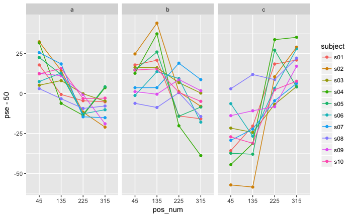

```r
ggplot(aes(pos_num, pse-50, color=subject, group=subject), data=df_pred) +
  geom_point() +
  geom_line() +
  facet_wrap(~identity, nrow=1)
```